# Harmful events and their economic consequences in US

Yadder Aceituno

December 10, 2017

## Synopsis

In US, storms, floods, hurricanes and a lot of different weather events cause damage to the country. This damage could be harmful to the poplutation or could bring economic consequences. This study will be over the NOAA’s database. it include records about different events in US since 1950. The main purpose for this study is to discover which events are the most harmful to people, and which are the event with bigger economic consquences.

## Loading libraries

First, I want to show you the libraries that I had used to complete my assignment.

```r
library(ggplot2);
library(dplyr);
```

## Data Loading

The data used for this analysis is provided by the teachers of the course in this [link(47Mb)](https://d396qusza40orc.cloudfront.net/repdata%2Fdata%2FStormData.csv.bz2).

The documentation of National Weather Service is in this [link](https://d396qusza40orc.cloudfront.net/repdata%2Fpeer2_doc%2Fpd01016005curr.pdf).

So, I have downloaded and unzipped the file and I renamed it as StormData.csv

```r
#Definning constants
STORM_DATA_FILE_NAME <- "StormData.csv";
EVENT_HEADER <- "Event";
VALUE_HEADER <- "Value";
DAMAGE_HEADER <- "Damage";
FATALITY_TYPE <- "Fatality";
INJURY_TYPE <- "Injury";
CROP_DAMAGE_TYPE <- "Crop Damage";
PROPERTY_DAMAGE_TYPE <- "Property Damage";
```

```r
#Loading data
storm_data <- read.csv(STORM_DATA_FILE_NAME);
```

Now, I’ll format some variables of the data frame

```r
#Casting date variables.
storm_data$BGN_DATE <- as.Date(storm_data$BGN_DATE, format = "%m/%d/%Y");
storm_data$END_DATE <- as.Date(storm_data$END_DATE, format = "%m/%d/%Y");

#Transforming exponent values
transform_exp <- function(element){
  if(length(element) > 0){
    if(!is.na(as.numeric(element)))
    {
      #All numeric 1..8 is 10
      10
    }else{
      #We have to find the correct value for the character
      switch(element,
             "K" = 10 ^ 3,
             "k" = 10 ^ 3,
             "H" = 10 ^ 2,
             "h" = 10 ^ 2,
             "M" =  10 ^ 6,
             "m" =  10 ^ 6,
             "B" = 10 ^ 9,
             "b" = 10 ^ 9,
             "+" = 1,
             "-" = 0,
             "?" = 0,
             0);
    }
  }else{
    #No characters, the value is zero
    0;
  }
};

#Getting the exponent value
storm_data$PROPDMGEXP_VALUE <- Vectorize(transform_exp)(as.character(storm_data$PROPDMGEXP));
storm_data$CROPDMGEXP_VALUE <- Vectorize(transform_exp)(as.character(storm_data$CROPDMGEXP));
```

## Data Processing

In this section I’ll try to find the most harmful events related to population health.

To achieve that, I’ll use the variables **FATALITIES** and **INJURIES**. With those variables I’ll try to plot the top 5 events with the most bigger quantities.

First, I’ll extract the information of the variables and then get the top 5 from each variable.

```r
#Aggregation of fatalities and injuries by event
fatalities_by_events <- aggregate(FATALITIES ~ EVTYPE, data = storm_data, sum);
injuries_by_events <- aggregate(INJURIES ~ EVTYPE, data = storm_data, sum);

#Getting top 5 of fatalities
fatalities_by_events <- arrange(fatalities_by_events, desc(FATALITIES));
top5_fatalities_by_events <- fatalities_by_events[1:5,];

#Getting top 5 of injuries
injuries_by_events <- arrange(injuries_by_events, desc(INJURIES));
top5_injuries_by_events <- injuries_by_events[1:5,];
```

Let’s look a plot with the information.

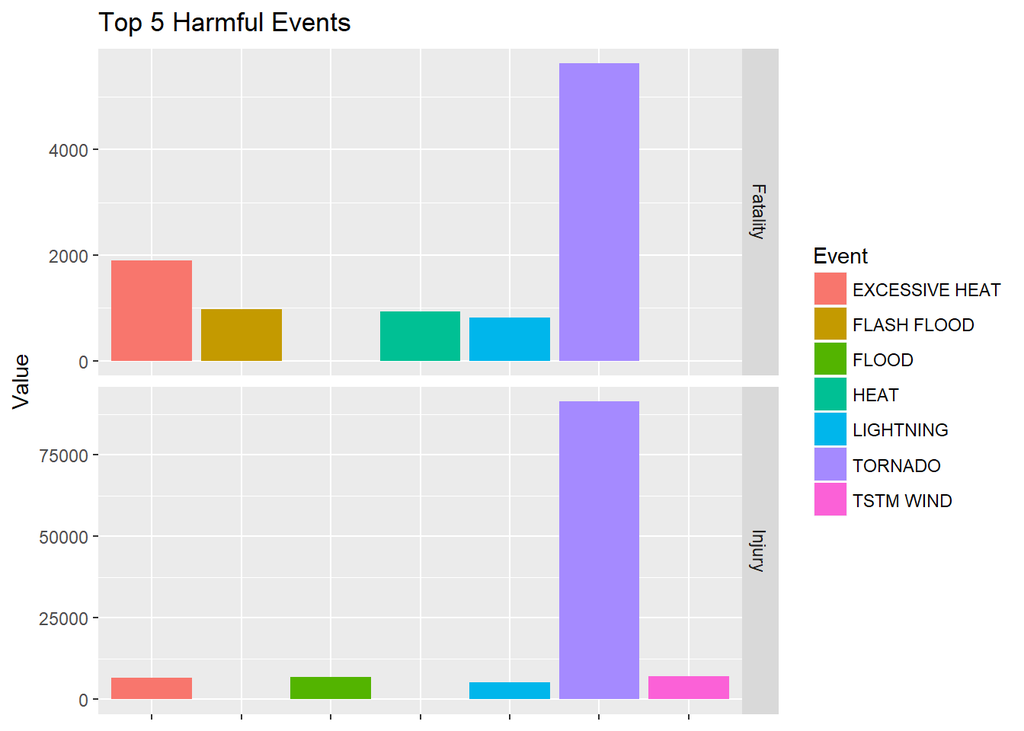

```r
#Changing column names
colnames(top5_fatalities_by_events)[1] <- EVENT_HEADER;
colnames(top5_injuries_by_events)[1] <- EVENT_HEADER;
colnames(top5_fatalities_by_events)[2] <- VALUE_HEADER;
colnames(top5_injuries_by_events)[2] <- VALUE_HEADER;

#Creating the dataframe to use for plotting
top5_fatalities_by_events$Type <- FATALITY_TYPE;
top5_injuries_by_events$Type <- INJURY_TYPE;
top5_harmful_events <- rbind(top5_fatalities_by_events, top5_injuries_by_events);

#Creating the plotting
g <- ggplot(top5_harmful_events, aes(x = factor(Event),y = Value, fill = Event));
gg <- g + geom_bar(stat="identity") +
  facet_grid(Type~., scales = "free_y") +
  labs(y="Value", title="Top 5 Harmful Events") +
  theme(axis.text.x =  element_blank(), axis.title.x = element_blank());
gg;
```

## Great Economic Consequences

In this section I’ll try to figure out which is the event with great economic consequences in the country.

To achieve that, I’ll use the variables **PROPDMGEXP_VALUE** and **CROPDMGEXP_VALUE**. With those variables I’ll try to plot the top 5 events with the most bigger quantities.

First, I’ll extract the information of the variables and then get the top 5 from each variable.

```r
storm_data$CROPDMG_VALUE <- storm_data$CROPDMG * storm_data$CROPDMGEXP_VALUE;
storm_data$PROPDMG_vALUE <- storm_data$PROPDMG * storm_data$PROPDMGEXP_VALUE;

#Aggregation of fatalities and injuries by event
cropdmg_by_events <- aggregate(CROPDMG_VALUE ~ EVTYPE, data = storm_data, sum);
propdmg_by_events <- aggregate(PROPDMG_vALUE ~ EVTYPE, data = storm_data, sum);

#Getting top 5 of crop damage
cropdmg_by_events <- arrange(cropdmg_by_events, desc(CROPDMG_VALUE));
top5_cropdmg_by_events <- cropdmg_by_events[1:5,];

#Getting top 5 of property damage
propdmg_by_events <- arrange(propdmg_by_events, desc(PROPDMG_vALUE));
top5_propdmg_by_events <- propdmg_by_events[1:5,];
```

Now, I’ll plot the information.

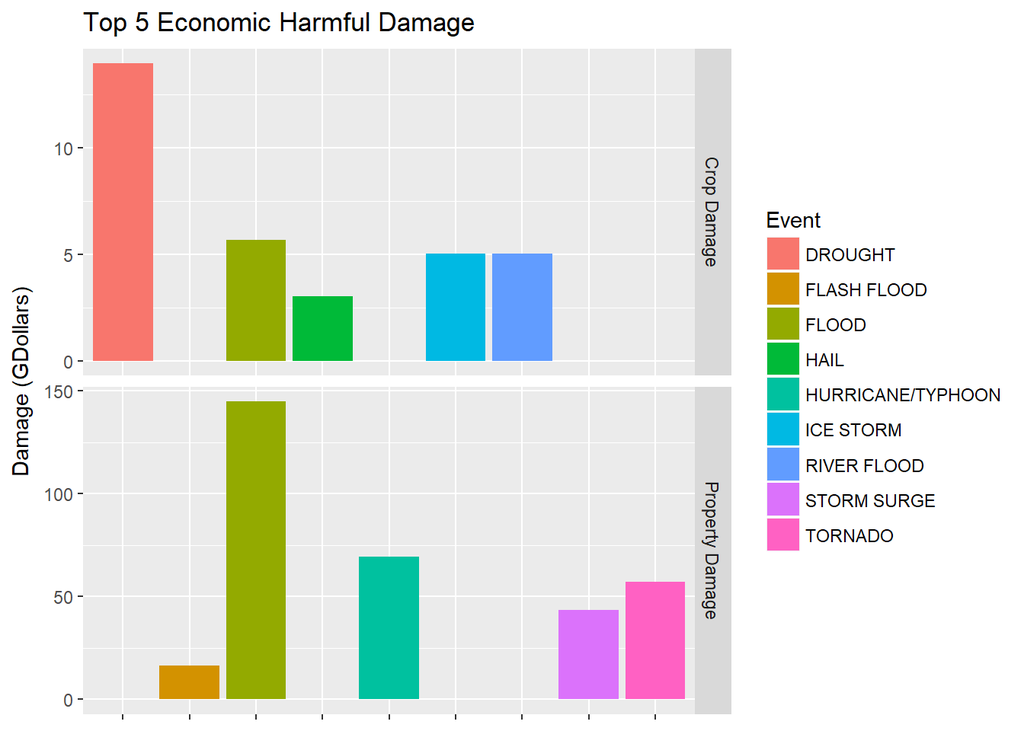

```r
#Changing column names
colnames(top5_cropdmg_by_events)[1] <- EVENT_HEADER;
colnames(top5_propdmg_by_events)[1] <- EVENT_HEADER;
colnames(top5_cropdmg_by_events)[2] <- DAMAGE_HEADER;
colnames(top5_propdmg_by_events)[2] <- DAMAGE_HEADER;

#Creating the dataframe to use for plotting
top5_cropdmg_by_events$Type <- CROP_DAMAGE_TYPE;
top5_propdmg_by_events$Type <- PROPERTY_DAMAGE_TYPE;
top5_economic_events <- rbind(top5_cropdmg_by_events, top5_propdmg_by_events);

#To remove scientific notation
options(scipen=999);

#Creating the plotting
g <- ggplot(top5_economic_events, aes(x = factor(Event),y = Damage / (10 ^ 9), fill = Event));
gg <- g + geom_bar(stat="identity") +
  facet_grid(Type~., scales = "free_y") +
  labs(y="Damage (GDollars)", title="Top 5 Economic Harmful Damage") +
  theme(axis.text.x =  element_blank(), axis.title.x = element_blank());
gg;
```

With that plot I conclude that the most economic harmful event is flood. Flood caused almost 150 GDollars of damage in property.

But, It’s important to consider that droughts could cause a great damage, drought caused almost 15 GDollars of damage in crops. So, it could cause a rise of prices of products related to crops.

## Results

We can see the results of harmful damage for population in this table:

```r
top5_harmful_events;
```

```
##             Event Value     Type
## 1         TORNADO  5633 Fatality
## 2  EXCESSIVE HEAT  1903 Fatality
## 3     FLASH FLOOD   978 Fatality
## 4            HEAT   937 Fatality
## 5       LIGHTNING   816 Fatality
## 6         TORNADO 91346   Injury
## 7       TSTM WIND  6957   Injury
## 8           FLOOD  6789   Injury
## 9  EXCESSIVE HEAT  6525   Injury
## 10      LIGHTNING  5230   Injury
```

And for economic damage, we can see the final results here:

```r
arrange(top5_economic_events, desc(Damage));
```

```
##                Event       Damage            Type
## 1              FLOOD 144657709800 Property Damage
## 2  HURRICANE/TYPHOON  69305840000 Property Damage
## 3            TORNADO  56937162897 Property Damage
## 4        STORM SURGE  43323536000 Property Damage
## 5        FLASH FLOOD  16140815011 Property Damage
## 6            DROUGHT  13972566000     Crop Damage
## 7              FLOOD   5661968450     Crop Damage
## 8        RIVER FLOOD   5029459000     Crop Damage
## 9          ICE STORM   5022113500     Crop Damage
## 10              HAIL   3025954650     Crop Damage
```

With this information we can see that the event with great economic consequences is Flood.